# Final Project

Kate Hickman

# Bacterial-Fungal Interactions in Mangrove Roots

## **Introduction**

This project aims to illuminate potential interactions between bacterial and fungal species in terms of community assembly. The analysis is multi-faceted and will include various comparisons between the subjects of research.

# **Data Analysis**

## Bacterial and Fungal Community Data

Let’s load the data and take a look at it:

```r
full <- readRDS("./bact_and_fungi_clean_ps_object")

kableExtra::kable(full@sam_data[1:5, ]) %>%
  kableExtra::kable_classic()
```

| x |
| --- |
| Avicennia alba |
| Avicennia alba |
| Avicennia alba |
| Avicennia alba |
| Avicennia alba |

| x |
| --- |
| AA_Mer_Le_05 |
| AA_Mer_Le_06 |
| AA_Sem_So_04 |
| AA_Sem_So_03 |
| AA_Mer_Le_09 |

| x |
| --- |
| FALSE |
| FALSE |
| FALSE |
| FALSE |
| FALSE |

| x |
| --- |
| Merang |
| Merang |
| Semakau |
| Semakau |
| Merang |

| x |
| --- |
| Leaf |
| Leaf |
| Sediment |
| Sediment |
| Leaf |

| x |
| --- |
| Lee_2019 |
| Lee_2019 |
| Lee_2019 |
| Lee_2019 |
| Lee_2019 |

| x |
| --- |
| SRR9187601 |
| SRR9187602 |
| SRR9187603 |
| SRR9187604 |
| SRR9187605 |

| x |
| --- |
| PRJNA545581 |
| PRJNA545581 |
| PRJNA545581 |
| PRJNA545581 |
| PRJNA545581 |

| x |
| --- |
| SAMN11897169 |
| SAMN11897170 |
| SAMN11897158 |
| SAMN11897157 |
| SAMN11897173 |

| x |
| --- |
| SRX5960051 |
| SRX5960050 |
| SRX5960049 |
| SRX5960048 |
| SRX5960047 |

| x |
| --- |
| Malaysia |
| Malaysia |
| Singapore |
| Singapore |
| Malaysia |

| x |
| --- |
| Asia |
| Asia |
| Asia |
| Asia |
| Asia |

| x |
| --- |
| Malaysia |
| Malaysia |
| Singapore |
| Singapore |
| Malaysia |

| x |
| --- |
| SRP200241 |
| SRP200241 |
| SRP200241 |
| SRP200241 |
| SRP200241 |

| x |
| --- |
| ./Data/Lee_2019/fastq/SRR9187601_pass_1.fastq.gz |
| ./Data/Lee_2019/fastq/SRR9187602_pass_1.fastq.gz |
| ./Data/Lee_2019/fastq/SRR9187603_pass_1.fastq.gz |
| ./Data/Lee_2019/fastq/SRR9187604_pass_1.fastq.gz |
| ./Data/Lee_2019/fastq/SRR9187605_pass_1.fastq.gz |

[output not shown]

| x |
| --- |
| NA |
| NA |
| NA |
| NA |
| NA |

| x |
| --- |
| Fungi |
| Fungi |
| Fungi |
| Fungi |
| Fungi |

| x |
| --- |
| 5.534833N 102.944331E |
| 5.534833N 102.944331E |
| 1.211727N 103.758781E |
| 1.211727N 103.758781E |
| 5.534833N 102.944331E |

| x |
| --- |
| 5.534833 |
| 5.534833 |
| 1.211727 |
| 1.211727 |
| 5.534833 |

| x |
| --- |
| 102.9443 |
| 102.9443 |
| 103.7588 |
| 103.7588 |
| 102.9443 |

| x |
| --- |
| 1912KMI-0007 |
| 1912KMI-0007 |
| 1912KMI-0007 |
| 1912KMI-0007 |
| 1912KMI-0007 |

Now that we can see the data, we’ll be focusing on Structure, Microbe, Lat and Long. WHY ARE ALL THE VARAIBLES “X”?

# **Analysis 1**

## MRM distance of geographical location and sample similarity

Let’s start this analysis by making a matrix with the geographical locations of the samples. Then we can make another matrix with the operational taxanomic units to display sample diversity.  
Once we have made those matrices, we can run a “multiple regression of matrices” test, using a response matrix (in this case otu_dist) as a function of the explanatory matrix (location_dist).

```r
lat <- full@sam_data$Lat %>% as.numeric()
lon <- full@sam_data$Lon %>% as.numeric()

location_dist <- data.frame(lat, lon) %>% dist()

glimpse(location_dist)
```

```
##  'dist' num [1:114003] 0 4.4 4.4 0 0 ...
##  - attr(*, "Size")= int 478
##  - attr(*, "Diag")= logi FALSE
##  - attr(*, "Upper")= logi FALSE
##  - attr(*, "method")= chr "euclidean"
##  - attr(*, "call")= language dist(x = .)
```

```r
otu_dist <- otu_table(full) %>% dist()

glimpse(otu_dist)
```

```
##  'dist' num [1:114003] 3899 8034 8386 6973 3756 ...
##  - attr(*, "Size")= int 478
##  - attr(*, "Labels")= chr [1:478] "AA_Mer_Le_05" "AA_Mer_Le_06" "AA_Sem_So_04" "AA_Sem_So_03" ...
##  - attr(*, "Diag")= logi FALSE
##  - attr(*, "Upper")= logi FALSE
##  - attr(*, "method")= chr "euclidean"
##  - attr(*, "call")= language dist(x = .)
```

```r
otu_dist <- vegan::vegdist(otu_table(full), na.rm = TRUE)

MRM1 <- ecodist::MRM(otu_dist ~ location_dist)

MRM1
```

[output not shown]

I SHOULD PROBABLY SINK THAT TO ANOTHER OUTPUT FILE… LET ME DOUBLE-CHECK. WHAT WOULD I DO WITH THE FILE AND WHAT WOULD BE THE POINT? SHOULD I ALSO REMOVE THE DISPLAYING OF THE MATRICES?  
P.S. both of those printed matrices look like shit  
While the p-value is statistically significant, the correlation between diversity and pxosimity is rather weak. Therefore, let’s run a few more tests to get a more definitive idea of what’s going on.

Aaaand just for funsies, let’s visualize the otu_dist as a heatmap:

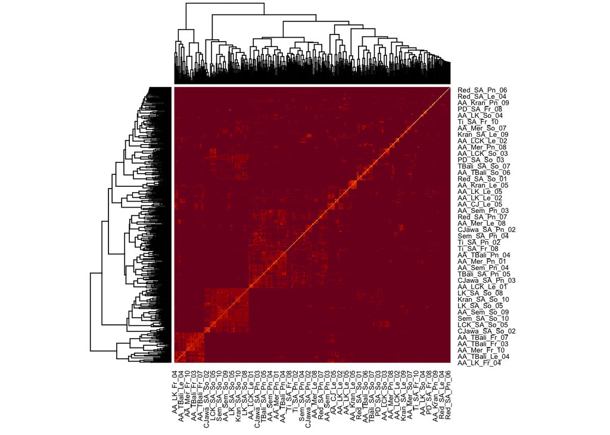

```r
otu_dist %>% as.matrix() %>% heatmap()
```

```r
samp <- data.frame(sample_data(full))

#glm(formula = "samp$Microbe" ~ "samp$Lon" + "samp$Lat", data = samp)
```

## Diversity of Phyla by Structure  
So rather than predict diversity by geographical proximity, how about we see how host structure plays into microbial community diversity.

After removing the “Blanks” from the sample data for Structure, we can create a stacked bar graph that displays various phyla and their relative abundance by structure.

```r
full@sam_data %>% names
```

```
##  [1] "Host"                           "SampleID"
##  [3] "PCR_Negative"                   "Location"
##  [5] "Structure"                      "Study"
##  [7] "Run"                            "BioProject"
##  [9] "BioSample"                      "Experiment"
## [11] "geo_loc_name_country"           "geo_loc_name_country_continent"
## [13] "geo_loc_name"                   "SRAStudy"
## [15] "Fwd_Path"                       "Rev_Path"
## [17] "SampleIDList"                   "Microbe"
## [19] "GPS"                            "Lat"
## [21] "Lon"                            "IlluminaRun"
```

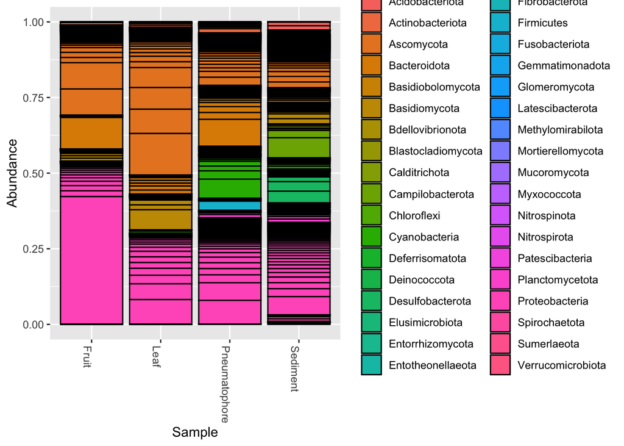

```r
full_structures <- full %>% subset_samples(Structure != "Blank")

# this shows phylum abundance by structure
merge_samples(full_structures, "Structure") %>%
  transform_sample_counts(fun = function(x){x/sum(x)}) %>%
  plot_bar(fill = "Phylum")
```

Now that we can visualize those relationships, how accurate are our perceptions of correlation? In other words, do the patterns we project correlate to reality? Let’s use a generalized linear model to find out.

```r
#glm(formula = "Microbe" ~ "Host" + "Structure", data = full_structures)
```

MUST FIGURE OUT HOW TO STOP THE TOP OF GRAPH FROM GETTING CUT-OFF

MUST ALSO KNOW WHY GLM ISN’T WORKING

There are a few Archaea samples in our data and I’m going to remove those, as they’re beyond the scope of this research. Then we can show a plot that gives relative abundance by Kingdom.

[figure not shown]

```r
full_nonarch <- subset_taxa(full, Kingdom != "Archaea")

# quick plot to look at kingdom-level taxonomy
full_nonarch %>%
  transform_sample_counts(function(x){x/sum(x)}) %>%
  plot_bar(fill="Kingdom")
```

SO.. HOW DOES STRUCTRE AFFECT DIVERSITY?? … AND WHY DOESN’T THIS GRAPH WORK?

# **Analysis 2**

## Alpha diversity and relative class abundance v location

Now that we’ve taken a look at structure, we can break down the Phyla distribution by host. We had two types of hosts in the data-collection: *Avicennia alba* and *Sonneratia alba*.  
The first graph shows the phyla distribution as differentiated by host. However, the downside to this graph is that the Phyla are sorted alphabetically rather than by microbe-type.  
The second graph has undergone some modification, based off a few suspicions: 1. I suspect both the host and the structure impact the diversity of the microbial community  
2. The impact of those variables will likely be different for Fungi vs. Bacteria  
Thus, the second graph shows a separate column for the outcome of the three variables interacting. The first 8 rows go through the structures of *Avicennia alba* by microbe, and the second 8 do the same thing for *Sonneratia alba*.

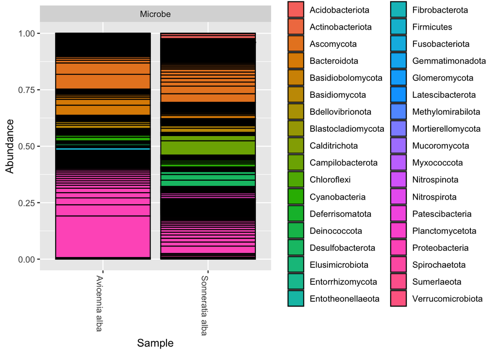

```r
full_nonarch %>%
  subset_samples(Host != "Blank") %>%
  merge_samples("Host") %>%
  transform_sample_counts(function(x){x/sum(x)}) %>%
  plot_bar(fill="Phylum") +
  facet_wrap(~"Microbe")
```

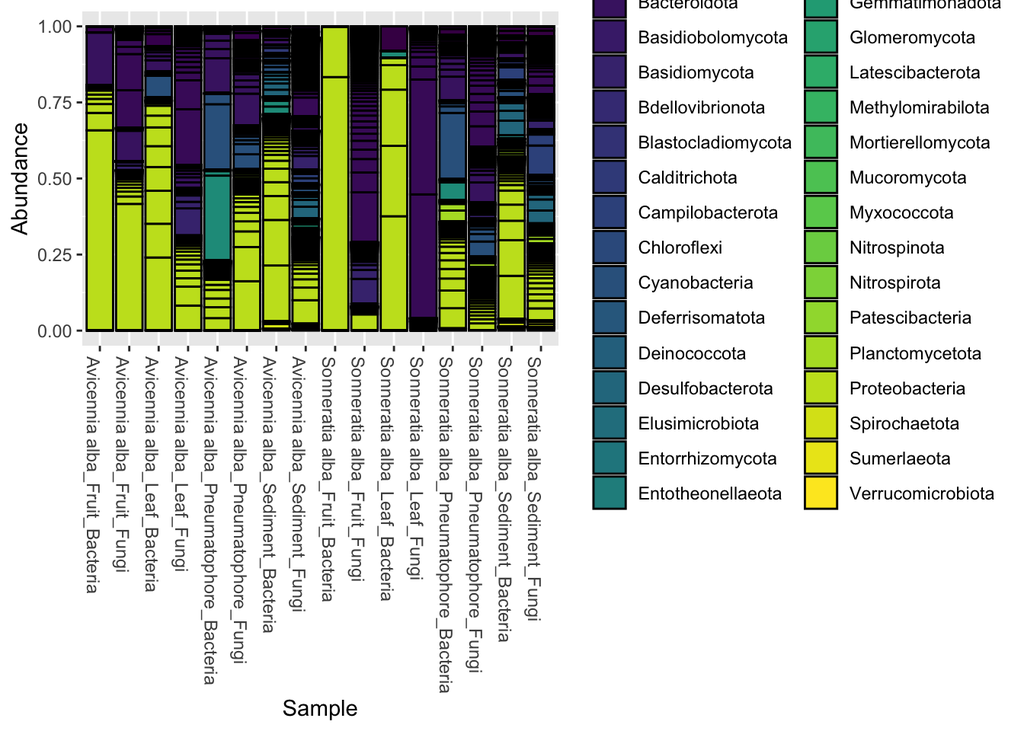

```r
newmerge <- paste0(full@sam_data$Host, "_", full@sam_data$Structure, "_", full@sam_data$Microbe)

full@sam_data$newmerge <- newmerge

full %>%
  subset_samples(Host != "Blank") %>%
  merge_samples("newmerge") %>%
  transform_sample_counts(function(x){x/sum(x)}) %>%
  plot_bar(fill="Phylum") +
  scale_fill_viridis_d()
```

LET’S MAKE THIS GRAPH LARGER  
Alright, so that graph is pretty hard to read. Merging those variables made the data a little messy, so it needs to be restored. Once that is accomplished, we can split the previous graph up into several graphs that make the data a bit more digestible.

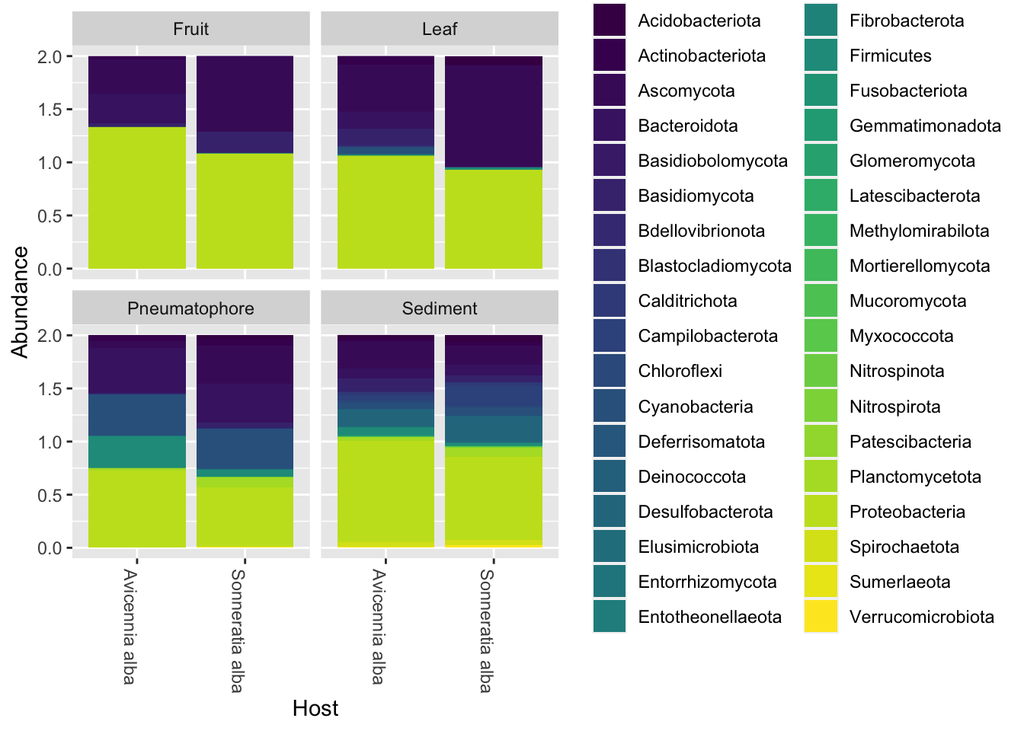

```r
# reassign the earlier plot
full2 <- full %>%
  subset_samples(Host != "Blank") %>%
  merge_samples("newmerge") %>%
  transform_sample_counts(function(x){x/sum(x)}) %>%
  plot_bar(fill="Phylum") +
  scale_fill_viridis_d()

# this will fix the otu_table slot
full2 <- full %>%
  subset_samples(Host != "Blank") %>%
  merge_samples("newmerge") %>%
  transform_sample_counts(function(x){x/sum(x)})

# this code repairs the variables that were damaged upon merging
full2@sam_data$Host <- row.names(full2@sam_data) %>% str_split("_") %>% map_chr(1)
full2@sam_data$Structure <- row.names(full2@sam_data) %>% str_split("_") %>% map_chr(2)
full2@sam_data$Microbe <- row.names(full2@sam_data) %>% str_split("_") %>% map_chr(3)

# this graph shows separate columns for each host, and is wrapped by structure
full2 %>%
  plot_bar2(x="Host", fill="Phylum")+
  scale_fill_viridis_d()+
  facet_wrap(~Structure)
```

Now that we can see the diversity of phyla split by host and structure, we can further our analysis to include the microbes.  
To show those same differences by microbe, we’ll make two graphs: one for bacteria, and another for fungi.

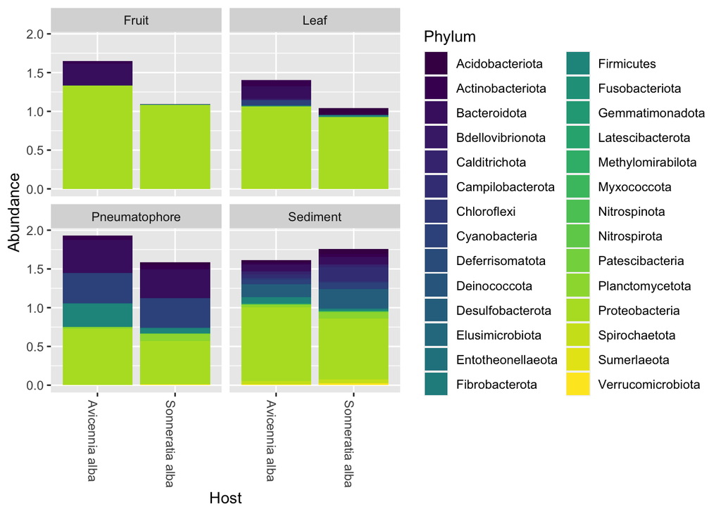

```r
# here is our bacterial plot
bact_plot <- full2 %>%
  subset_taxa(Kingdom =="Bacteria") %>%
  plot_bar2(x="Host", fill="Phylum")+
  scale_fill_viridis_d()+
  facet_wrap(~Structure)

bact_plot
```

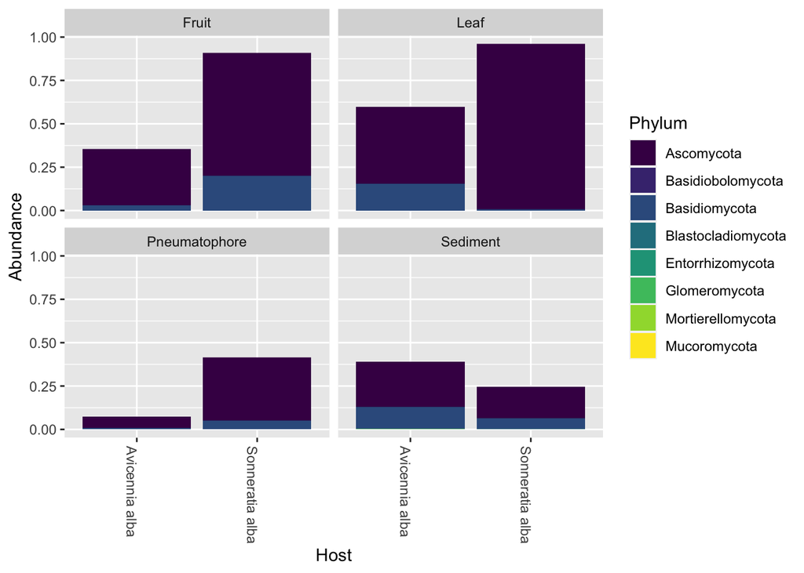

```r
# here is our fungal plot
fung_plot <- full2 %>%
  subset_taxa(Kingdom =="Fungi") %>%
  plot_bar2(x="Host", fill="Phylum")+
  scale_fill_viridis_d()+
  facet_wrap(~Structure)

fung_plot
```

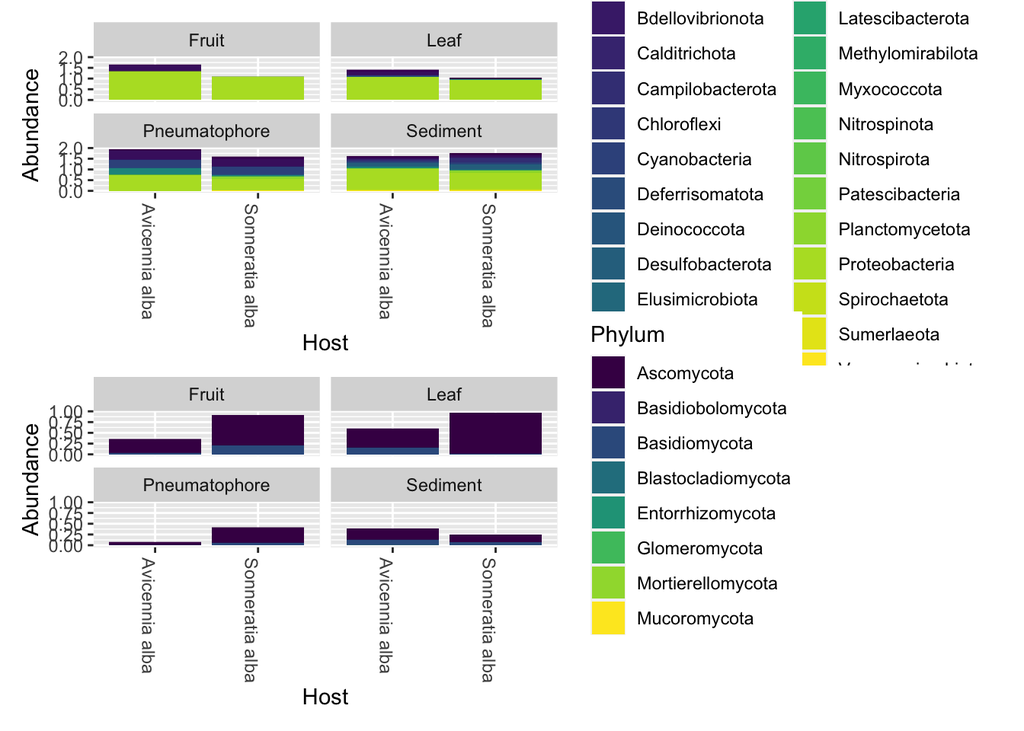

```r
# this will combine the plots to show phyla sorted by kingdom
bact_plot / fung_plot
```

THESE AXES NEED TO BE MESSED WITH: make the y-axes say fungal/bacterial abundance, fix the legend

PROBABLY WANT FEWER BAR GRAPHS AND MORE ANALYSES THROUGHOUT

# **Analysis 3**

Now that we’ve demonstrated that diversity exists, and is impacted by several different variables, it would be prudent to know how many different alpha-diversity metrics we’re working with. The estimate_richness() and plot_richness() functions are helpful in this analysis. This will help us to understand the ecological structure of the community in terms of richness and / or evenness.  
## Species Richness

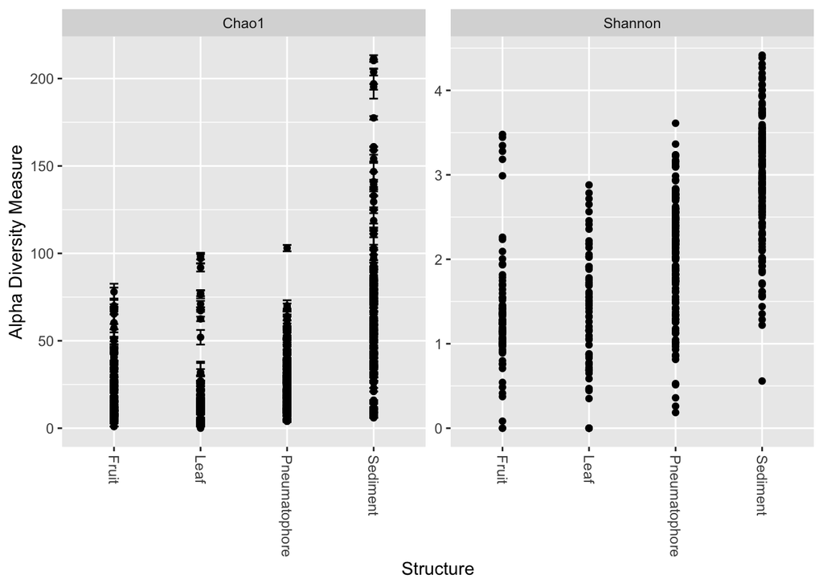

```r
# this pruning prepares the data for richness
GP <- prune_species(speciesSums(full) > 0, full)

# this graph wraps by diversity type (Chao1, Shannon) and separates based on structure
GP %>%
  subset_samples(Host != "Blank") %>%
  plot_richness(x = "Structure",
              measures=c("Chao1", "Shannon"),
              sortby = "Observed")
```

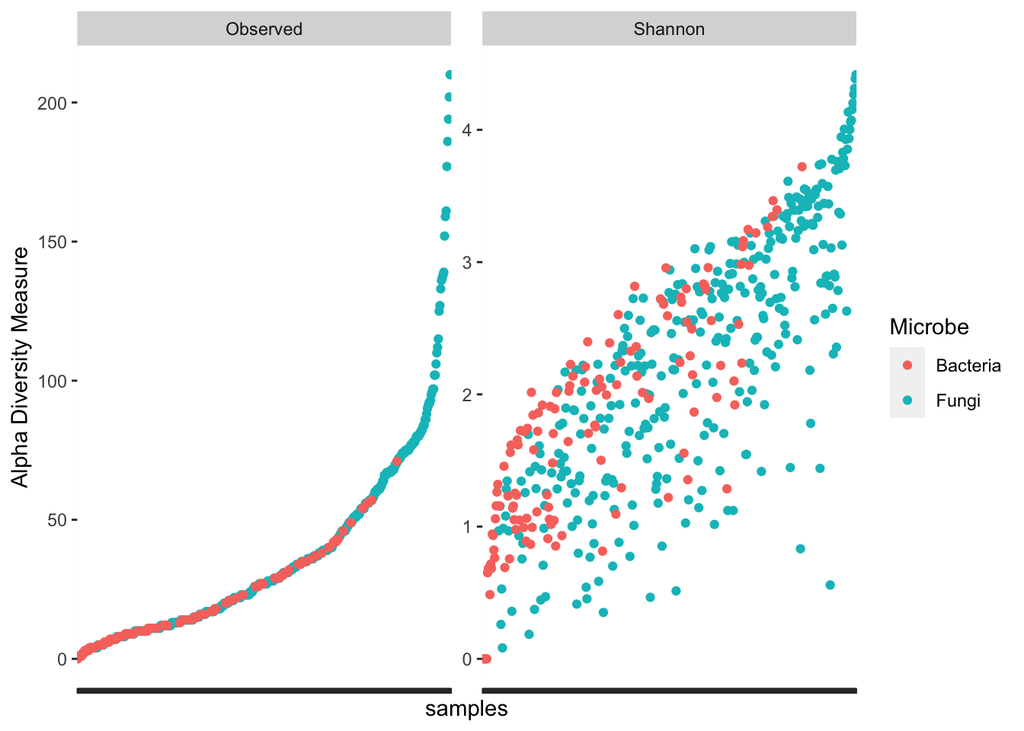

```r
# colored by kingdom/microbe
plot_richness(full, measures = c("Observed","Shannon"),
              color = "Microbe",
              sortby = "Observed") +
  theme(axis.text.x = element_blank())
```

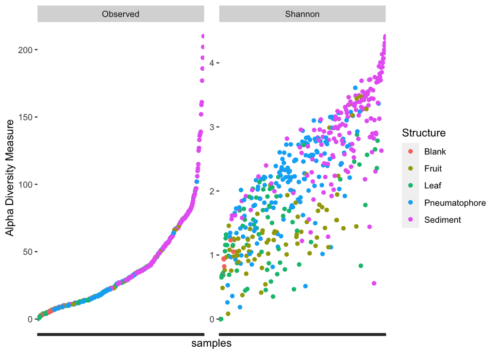

```r
# colored by structure
plot_richness(full,
              measures = c("Observed","Shannon"),
              color = "Structure",
              sortby = "Observed") +
  theme(axis.text.x = element_blank())
```

These graphs demonstrate the greater speciosity and diversity of fungal species, as well as the richness in sediments. HELP WITH HOW TO READ THEM EXACTLY  
Grouping by the microbe and utilizing a boxplot clarifies the data visually.

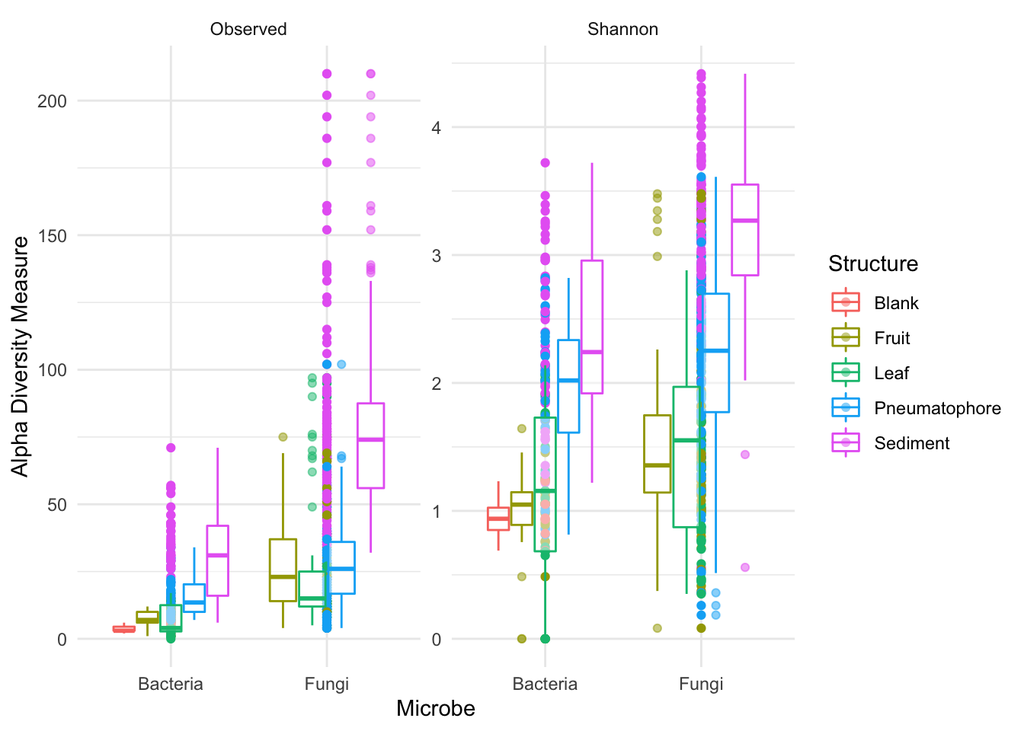

```r
plot_richness(full,
              x = "Microbe",
              measures = c("Observed","Shannon"),
              color = "Structure",
              sortby = "Observed") +
  geom_boxplot(alpha = .5) +
  theme_minimal()
```

CREATE A FOLDER FOR GRAPHS AND EXPORT THEM